# Random Forest in the Health Industry

An analysis of the random forest algorithm and its applications in the health industry

Author

Maddie Sortino and Jisa Jose (Advisor: Dr. Cohen)

Published

April 14, 2025

Slides: slides.html ( Go to `slides.qmd` to edit)

Literature Review: litreview.html

## Introduction

Machine learning has significantly advanced predictive analytics, particularly in the medical industry and clinical decision-making. Among the many available algorithms, Random Forest (RF) has emerged as a powerful tool due to its ability to handle high-dimensional data, resistance to overfitting, and high accuracy in predicting medical events (Rigatti 2017). RF is an ensemble learning method composed of multiple decision trees, which are generated through bagging and random feature selection. The combined efforts of these trees in bootstrap aggregation allow for superior classification and regression predictions compared to classical statistical models (Biau and Scornet 2016). This flexibility enables biomedical experts to tackle various tasks, including cancer survival analysis, disease progression prediction, and healthcare resource optimization.

One of the most notable applications of RF in healthcare is survival analysis, particularly in colon cancer research. Studies utilizing SEER data have compared RF to the Cox proportional hazards model, highlighting RF’s ability to handle missing data and complex interactions more effectively (Breiman 2001). Additionally, RF has been widely used in clinical decision-making, such as predicting ICU patient outcomes and identifying those at high risk of sepsis.Another critical application is diabetes prediction and prevention. RF not only forecasts diabetes development but also provides personalized recommendations to healthcare professionals, helping them implement preventive measures and improve patient outcomes(Khine and Tun 2022).

Beyond diagnostics, RF is also instrumental in handling imbalanced datasets. For instance, in predicting disease susceptibility, random subsampling techniques within RF have been shown to outperform other machine learning models such as support vector machines, boosting, and bagging (Khalilia, Chakraborty, and Popescu 2011). Furthermore, RF has been used in healthcare resource planning, such as forecasting the demand for essential medications in public health facilities to ensure supply chain efficiency and prevent shortages (Mbonyinshuti, Nshimiyimana, and Uwitonze 2022).

RF is a powerful algorithm, but it also has its challenges. Hyperparameter tuning is crucial for maximizing predictive accuracy, with factors such as the number of trees (L), sample size per tree, and the number of variables considered at each split (mtry) all significantly influencing model performance (Probst, Wright, and Boulesteix 2019b). While RF often performs well with default settings, fine-tuning these parameters can enhance both reliability and speed (Boulesteix et al. 2012). However, the major drawback remains model interpretability, which is critical in medical decision-making. Researchers have proposed methods such as conditional inference forests (CIF) to improve reliability while reducing bias in variable selection (Dai et al. 2018).

Since RF was first introduced to clinical diagnostics, it has been regarded as one of the most effective tools in medical prediction models. This study explores its performance compared to traditional statistical techniques and evaluates whether advancements in hyperparameter optimization can further enhance its effectiveness. By synthesizing insights from multiple sources, this analysis provides a comprehensive understanding of RF’s potential in healthcare analytics while identifying areas for further refinement.

In this study, we use the Random Forest algorithm on a clinical dataset with the goal of predicting heart disease. Our first step involves data exploration and preprocessing, which is later followed by training and evaluating a baseline decision tree model. After this, we create a Random Forest model and fine-tune it with cross-validation. To evaluate our model, we calculate accuracy, precision, recall, F1-score, AUC-ROC, and analyze feature importance to invoke relevance of the clinical reasoning behind the main predictors. With this endeavor, we strive to understand the practicality of exploiting Random Forest in real-world healthcare analytics and decision support systems.

## Methods

The random forest algorithm generates numerous decision trees using randomization and then aggregates the output of these trees into one output. A decision tree is an algorithm that has a ‘tree-like’ structure, consisting of a root node, branches, internal nodes and leaf nodes. The root node branches out into internal nodes, and depending on the outcome of each internal node, it ultimately leads to the leaf node; or the final outcome, or decision. In the formation of a random forest, a voting method is used for classification and an averaging method for regression. Randomization is done in two steps. The first uses bootstrap aggregation or bagging at the data set level, creating new randomized samples for the model development and testing. Bagging consists of randomly sampling from the original data set with replacement, ensuring the sample set is completely random. The data that is not used in the sampled data set is considered the out-of-bag (OOB) data. The next level of randomization happens at the decision node level. A certain number of predictors are chosen, which is often the square root of the number of predictors in the data set. The algorithm tests all possible thresholds for all selected variables and chooses the variable-threshold combination which results in the best split – the split which most effectively separates cases from controls, for instance (Rigatti 2017). This random selection of variables and threshold testing continues until either “pure” nodes are reached (containing only cases or controls) or some pre-defined endpoint (Rigatti 2017).

*Hyper parameters Overview*

Table 1 below shows a summary of the different hyperparameters of random forest and typical default values. Here, n is the number of observations and p is the number of variables in the dataset.

```r
table = data.frame(Hyperparameter = c("mtry",
                                      "Sample size",
                                      "Replacement",
                                      "Node size",
                                      "Number of trees",
                                      "Splitting rule"),
Description = c("Number of drawn candidate variables in each split",
                "Number of observations that are drawn for each tree",
                "Draw observations with or without replacement",
                "Minimum number of observations in a terminal node",
                "Number of trees in a forest",
                "Splitting criteria in the nodes"),
"Typical Default Values" = c("sqrt(p), p/3 for regression",
                           "n",
                           "TRUE (with replacement)",
                           "1 for classification, 5 for regression",
                           "500, 1,000",
                           "Gini impurity, p value, random")
)

knitr::kable(table,
             caption = "Overview of the different hyperparameters",
             col.names = c("Hyperparameter",
                           "Description",
                           "Typical Default Values"))
```

Overview of the different hyperparameters

| Hyperparameter | Description | Typical Default Values |
| --- | --- | --- |
| mtry | Number of drawn candidate variables in each split | sqrt(p), p/3 for regression |
| Sample size | Number of observations that are drawn for each tree | n |
| Replacement | Draw observations with or without replacement | TRUE (with replacement) |
| Node size | Minimum number of observations in a terminal node | 1 for classification, 5 for regression |
| Number of trees | Number of trees in a forest | 500, 1,000 |
| Splitting rule | Splitting criteria in the nodes | Gini impurity, p value, random |

Table 1. (Probst, Wright, and Boulesteix 2019b)

Table 1 provides an overview of the hyperparameters available to tune the decision forest, along with the recommended or default values. The decision forest algorithm is designed to work well without much tuning. It’s been found that an increased number of trees provides a better output, but there’s typically a limit in which there’s no more gain in accuracy, and only a decrease or slow down in performance with too many trees. The hyperparameter ‘mtry’ has been found to have the most influence, where the best value of ‘mtry’ depends on the number of variables that are related to the outcome (Probst, Wright, and Boulesteix 2019b).

*Gini Impurity*

The random forest algorithm uses the Gini measure of impurity to select the split with the lowest impurity at every node (Khalilia, Chakraborty, and Popescu 2011). The gini impurity can range between 0 - 0.5, with the lower the impurity, the better the split. If a gini impurity is 0, this means it is a ‘pure’ node and does not need to be split further. The formula for Gini Impurity is below, where p is the probability of samples belonging to the class i at a specific node.

$$Gini = 1 -\sum_{i = 1}^{n}{(p_i)^2}$$

*Random Forest Implementation in the Dataset*

The random forest model will be applied to analyze the dataset containing multiple clinical and demographic factors. This dataset has features like Age, Sex, Type of Chest Pain, Resting Blood Pressure (RestingBP), Cholesterol level, Fasting Blood Sugar (FastingBS), Electrocardiogram Results when at Rest (RestingECG), Maximum Heart Rate attained (MaxHR), Angina induced by exercise, Oldpeak, and ST Slope. The model will be fitted to the data so the presence or lack of heart disease (HeartDisease) can be predicted. This variable is the target (0 - No Heart Disease, 1 - Heart Disease).

*Model Training*

*Model Evaluation and Performance Metrics*

For the model evaluation, the following metrics will be applied:

- AUC-ROC Score: Evaluates the model’s classification capability for distinguishing classes (Heart Disease vs. No Heart Disease) (Probst, Wright, and Boulesteix 2019a). The AUC ROC Score is the area under the curve of the ROC (receiver-operating characteristic curve) curve. The ROC curve graphs the true positive rate over the false positive rate. The higher the ROC AUC, the better.
  $$\text{AUC-ROC} = \int_{0}^{1} \text{TPR} \left( \text{FPR}^{-1}(x) \right) \, dx$$
- Precision: Precision is the ratio of the true positive predictions to the total number of positive predictions
  $$Precision = \frac{True Positives}{(True Positives + False Positives)}$$
- Recall (Sensitivity): Recall is the ratio of the true positive predictions to all the actual positive instances:
  $$\text{Recall} = \frac{TruePositives}{TruePositives + FalseNegatives}$$
- F1-score: F1 score is the average of precision and recall.
  $$F1 = \frac{2*(Precision*Recall)}{(Precision + Recall)}$$

*Advantages/Disadvantages*

The random forests method remains one of the most robust and versatile methods for solving classification tasks, especially in the healthcare sector. Their capability to manage high dimensional data, model intricate relationships, and rank order features makes them particularly useful in disease prediction and risk factor evaluation (Breiman 2001). All of these benefits come with caveats. While random forests are robust in overfitting and are efficient with missing values (Khalilia, Chakraborty, and Popescu 2011), they also demand above-average computing power, can be inefficient with time on large databases, and are less clear than logistic regression models (Probst, Wright, and Boulesteix 2019a). Imposing certain values to parameters improves these shortcomings but not without a loss of performance and efficiency in specific datasets. Regardless, random forests are still a good choice in predictive modeling in medical research and decision support systems (Biau and Scornet 2016).

In summary the Random Forest algorithm has been used in this study because of its compatibility with structured clinical datasets and its ability to integrate categorical and numerical data without significant preprocessing (Breiman 2001). In contrast to logistic regression, which applies a mode of linearity, Random Forest is able to capture complex non-linear relationships in healthcare data (Probst, Wright, and Boulesteix 2019a). Another advantage of Random Forest is its provision of feature importance indices, which enhances the model’s interpretability by medical practitioners concerning risk prediction and proactive measures’ implementation(Khalilia, Chakraborty, and Popescu 2011)

## Analysis and Results

### Data Exploration and Visualization

*Data Set Overview*

Data Set: [Heart Failure Prediction Data](https://www.kaggle.com/datasets/fedesoriano/heart-failure-prediction/data)

This data set is a compilation of five different data sets from around the world. It contains 11 features: age, sex, chest pain type, resting blood pressure, cholesterol, fasting blood sugar, resting electrocardiogram results, max heart rate, exercise-induced angina, old peak, and slope of peak exercise ST segment. The data set is used to predict whether the patient has heart disease or not.

```r
#Loading packages
library(readr)
library(caret)
library(ggplot2)
library(tidyverse)
library(gridExtra)
library(scales)
library(data.table)
library(knitr)
#install.packages("gtsummary")
library(gtsummary)

#read data to dataframe
data <- read.csv('heart.csv')
#head(data,5)
```

*Table 1: Data Structure Overview*

```r
# Convert to a data.table
data_dt <- as.data.table(data)

# Create the structure table with Column, Type, and Sample Values
structure_table <- data_dt[, .(Column = names(data_dt),
                               Type = sapply(data_dt, class),
                               values = lapply(data_dt, function(x) paste(head(x, 5), collapse = ", ")))]

# display the table
kable(structure_table, caption = "Data Structure Overview")
```

Data Structure Overview

| Column | Type | values |
| --- | --- | --- |
| Age | integer | 40, 49, 37, 48, 54 |
| Sex | character | M, F, M, F, M |
| ChestPainType | character | ATA, NAP, ATA, ASY, NAP |
| RestingBP | integer | 140, 160, 130, 138, 150 |
| Cholesterol | integer | 289, 180, 283, 214, 195 |
| FastingBS | integer | 0, 0, 0, 0, 0 |
| RestingECG | character | Normal, Normal, ST, Normal, Normal |
| MaxHR | integer | 172, 156, 98, 108, 122 |
| ExerciseAngina | character | N, N, N, Y, N |
| Oldpeak | numeric | 0, 1, 0, 1.5, 0 |
| ST_Slope | character | Up, Flat, Up, Flat, Up |
| HeartDisease | integer | 0, 1, 0, 1, 0 |

(Table 1: Data structure overview of Heart Disease dataset)

The data structure overview table is an essential starting point for working with the heart disease prediction dataset. The table contains column names, data types, and examples for every feature as a sample overview of the dataset. All columns within the dataset are associated to some clinically significant feature which have the potential to be used for estimating the risk of heart disease.

*Table 2: Summary Statistics*

```r
# statistics of the dataset
tbl_summary(data)
```

| **Characteristic** | **N = 918**<sup>1</sup> |
| --- | --- |
| Age | 54 (47, 60) |
| Sex |  |
| F | 193 (21%) |
| M | 725 (79%) |
| ChestPainType |  |
| ASY | 496 (54%) |
| ATA | 173 (19%) |
| NAP | 203 (22%) |
| TA | 46 (5.0%) |
| RestingBP | 130 (120, 140) |
| Cholesterol | 223 (173, 267) |
| FastingBS | 214 (23%) |
| RestingECG |  |
| LVH | 188 (20%) |
| Normal | 552 (60%) |
| ST | 178 (19%) |
| MaxHR | 138 (120, 156) |
| ExerciseAngina |  |
| N | 547 (60%) |
| Y | 371 (40%) |
| Oldpeak | 0.60 (0.00, 1.50) |
| ST_Slope |  |
| Down | 63 (6.9%) |
| Flat | 460 (50%) |
| Up | 395 (43%) |
| HeartDisease | 508 (55%) |

<sup>1</sup> Median (Q1, Q3); n (%)

(Table 2: Summary Statistics of Heart Disease dataset)

The dataset comprises of 918 records and 11 features which include both categorical and numerical variables that help assess heart disease risk. Key variables indicating the health of patients include Age, Resting Blood Pressure (RestingBP), Cholesterol, Maximum Heart Rate (MaxHR), and ST Depression (Oldpeak) among others. It has no missing or duplicate values. It is also noted from the data that there are more male patients (79%) than female patients (21%) which may be noteworthy for analysis. More than half of the patients (54%) however do not experience chest pain (ASY) which is rather puzzling despite the patient potentially having heart disease. In addition, the variable depicting the target i.e. HeartDisease is relatively balanced with 55.3 percent of patients diagnosed to have heart disease and 44.7 percent of patients with no heart disease. Also, RestingBP and Cholesterol value of 0 may need some consideration as they are unrealistic and require correction prior to analysis.

*Figure 1: Distribution of some Features*

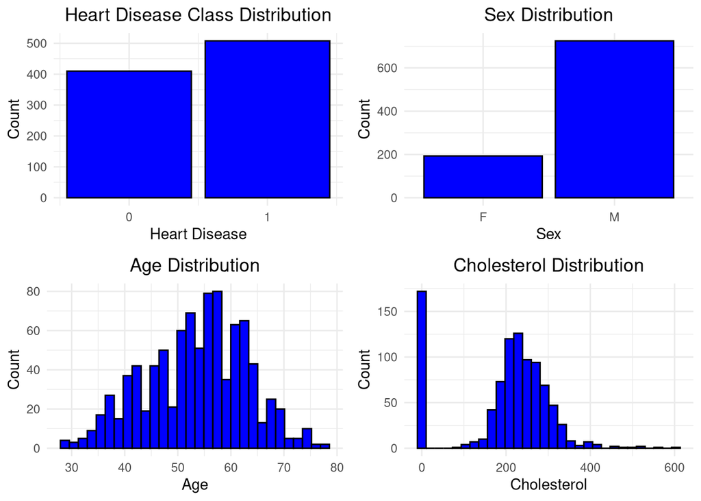

```r
# The distribution of 'Age' with a histogram - normal distribution
ageplot <- ggplot(data, aes(x = Age)) +
  geom_histogram(bins = 30, fill = "blue", color = "black") +
  theme_minimal() +
  theme(plot.title = element_text(hjust = 0.5)) +
  labs(title = "Age Distribution", x = "Age", y = "Count")

# The distribution of 'Heart Disease' with a histogram - no class imbalance
hdplot <- ggplot(data, aes(x = HeartDisease)) +
  geom_bar(fill = "blue", color = "black") +
  theme_minimal() +
  theme(plot.title = element_text(hjust = 0.5)) +
  scale_x_continuous(breaks=c(0,1)) +
  labs(title = "Heart Disease Class Distribution", x = "Heart Disease", y = "Count")

# The distribution of 'Sex' with a histogram - imbalance: ~4x more males than females
splot <- ggplot(data, aes(x = Sex)) +
  geom_bar(fill = "blue", color = "black") +
  theme_minimal() +
  theme(plot.title = element_text(hjust = 0.5)) +
  labs(title = "Sex Distribution", x = "Sex", y = "Count")

# The distribution of 'Cholesterol' with a histogram - over 150 records with a cholesterol of 0; otherwise normal distribution
cplot <- ggplot(data, aes(x = Cholesterol)) +
  geom_histogram(fill = "blue", color = "black") +
  theme_minimal() +
  theme(plot.title = element_text(hjust = 0.5)) +
  labs(title = "Cholesterol Distribution", x = "Cholesterol", y = "Count")

grid.arrange(hdplot, splot, ageplot, cplot, ncol = 2, nrow=2)
```

(Figure 1: Pictorical representation of some of distribution/trends of Heart Disease data set)

Figure 1 outlines some distribution/trends which are relevant in predicting heart diseases.

- **Heart Disease Distribution (Top-Left):** The distribution is appropriately balanced, minimizing the chances of bias in the model.
- **Sex Distribution (Top-Right):** The dataset has more male patients than female, which might impact predictions.
- **Age Distribution (Bottom-Left):** Most patients fall within the 40-70 years age range, which may reduce model accuracy for younger individuals.
- **Cholesterol Distribution (Bottom-Right):** The presence of zero values in cholesterol is unrealistic, indicating the need for data cleaning.

*Figure 2: Correlation Matrix – Understanding Key Relationships*

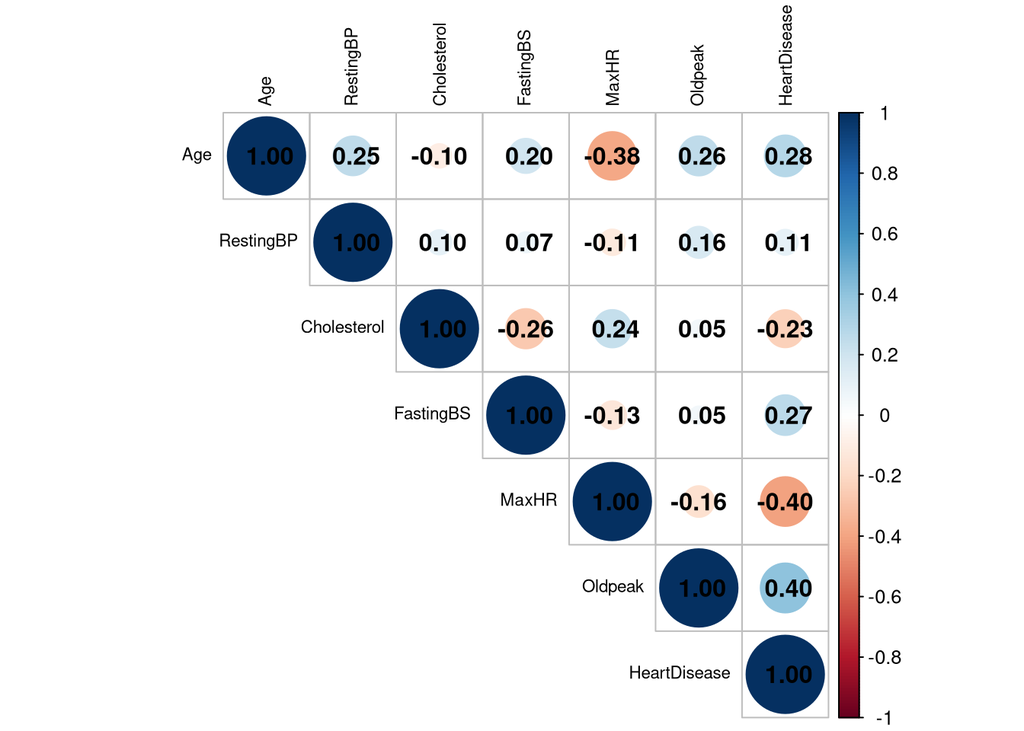

```r
# correlation matrix for numeric features
library(corrplot)
numeric_data <- data %>% select(where(is.numeric))
cor_matrix <- cor(numeric_data)
corrplot(cor_matrix, method = "circle", type = "upper",
         tl.col = "black", tl.cex = 0.7, addCoef.col = "black")
```

(Figure 2: Relationships of features in dataset with heart disease)

### Modeling and Results

In this section, we will begin with performing any necessary cleaning and preprocessing of the data. We will then use the decision tree algorithm to demonstrate how a decision tree works, and show the performance of one tree. The next step will be using the random forest algorithm, which is a combination of decision trees, to see how it performs in comparison, ideally providing a more accurate prediction.

*Data Preprocessing and Cleaning*

While there was no null or NA missing values found in the data set, we did find that there were some RestingBP and Cholesterol values of 0. There was one row with a RestingBP = 0 and 172 rows with Cholesterol = 0. We decided to drop these rows from the data set, as they were missing valid data.

```r
#Remove the bad data
newdata <- data[data$Cholesterol != 0, ]

bp0 <- sum(newdata$RestingBP == '0') #results in 0
cho <- sum(newdata$Cholesterol == '0') #results in 0
```

Our next step is to encode the data. The random forest alogorithm, along with most machine learning algorithms, functions best with numerical values. Therefore, we will transform the categorical variables to numeric. We will use one-hot encoding to transform the categorical variables into a binary column that indicates the presense (1) or absence (0) of the category.

*Encoded Data Preview*

```r
library(caret)
dmy <- dummyVars(" ~ .", data = newdata)
encoded <- data.frame(predict(dmy, newdata = newdata))
encoded$HeartDisease <- as.factor(encoded$HeartDisease)
kable(encoded[1:3, ])
```

| Age | SexF | SexM | ChestPainTypeASY | ChestPainTypeATA | ChestPainTypeNAP | ChestPainTypeTA | RestingBP | Cholesterol | FastingBS | RestingECGLVH | RestingECGNormal | RestingECGST | MaxHR | ExerciseAnginaN | ExerciseAnginaY | Oldpeak | ST_SlopeDown | ST_SlopeFlat | ST_SlopeUp | HeartDisease |
| --- | --- | --- | --- | --- | --- | --- | --- | --- | --- | --- | --- | --- | --- | --- | --- | --- | --- | --- | --- | --- |
| 40 | 0 | 1 | 0 | 1 | 0 | 0 | 140 | 289 | 0 | 0 | 1 | 0 | 172 | 1 | 0 | 0 | 0 | 0 | 1 | 0 |
| 49 | 1 | 0 | 0 | 0 | 1 | 0 | 160 | 180 | 0 | 0 | 1 | 0 | 156 | 1 | 0 | 1 | 0 | 1 | 0 | 1 |
| 37 | 0 | 1 | 0 | 1 | 0 | 0 | 130 | 283 | 0 | 0 | 0 | 1 | 98 | 1 | 0 | 0 | 0 | 0 | 1 | 0 |

*Splitting the Data* (70% Train and 30% Test)

We split the data set into training and test subsets. The training subset will contain 70% of the data, and the test subset will contain 30% of the data.

```r
#install.packages("caTools")
library(caTools)
## set seed for reproducibility
set.seed(555)

ind = sample.split(Y = encoded$HeartDisease, SplitRatio = 0.7)

#subsetting into Train data
train = encoded[ind,]

#subsetting into Test data
test = encoded[!ind,]
```

*Model Fitting and Prediction*

**Decision Tree**

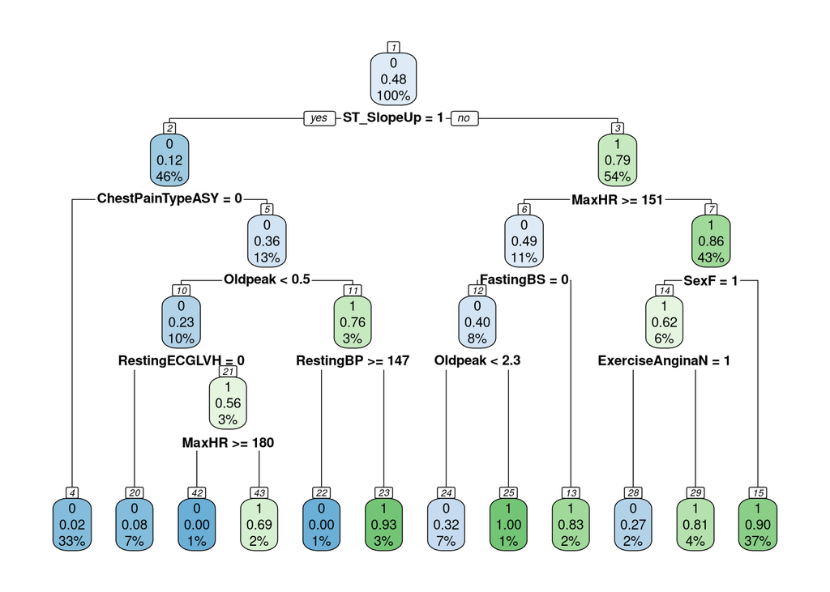

```r
library(rpart)
library(rpart.plot)
library(caret)
tree <- rpart(HeartDisease ~ .,
                    data = train,
                    method = "class",
                    control = rpart.control(minsplit = 10, cp = 0.01))

rpart.plot(tree, box.palette = "auto", nn = TRUE)
```

```r
predictions <- predict(tree, test, type = "class")
```

(Figure 3: Visualization of a Single Decision Tree Used in Heart Disease Classification)

**Random Forest**

```r
library(randomForest)
rf <- randomForest(HeartDisease ~ .,
                        data = train,
                        n_tree=100)
#print(rf)

prediction <- predict(rf, newdata = test)
```

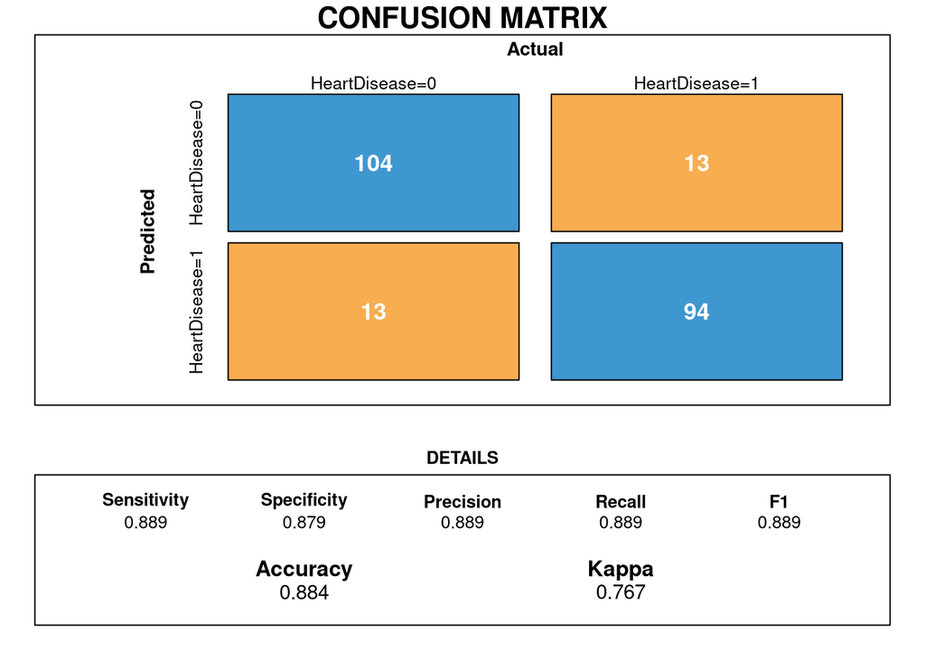

```r
cm <- confusionMatrix(prediction, test$HeartDisease)

draw_confusion_matrix <- function(cm) {

  layout(matrix(c(1,1,2)))
  par(mar=c(2,2,2,2))
  plot(c(100, 345), c(300, 450), type = "n", xlab="", ylab="", xaxt='n', yaxt='n')
  title('CONFUSION MATRIX', cex.main=2)

  # create the matrix
  rect(150, 430, 240, 370, col='#3F97D0')
  text(195, 435, 'HeartDisease=0', cex=1.2)
  rect(250, 430, 340, 370, col='#F7AD50')
  text(295, 435, 'HeartDisease=1', cex=1.2)
  text(125, 370, 'Predicted', cex=1.3, srt=90, font=2)
  text(245, 450, 'Actual', cex=1.3, font=2)
  rect(150, 305, 240, 365, col='#F7AD50')
  rect(250, 305, 340, 365, col='#3F97D0')
  text(140, 400, 'HeartDisease=0', cex=1.2, srt=90)
  text(140, 335, 'HeartDisease=1', cex=1.2, srt=90)

  # add in the cm results
  res <- as.numeric(cm$table)
  text(195, 400, res[1], cex=1.6, font=2, col='white')
  text(195, 335, res[2], cex=1.6, font=2, col='white')
  text(295, 400, res[3], cex=1.6, font=2, col='white')
  text(295, 335, res[4], cex=1.6, font=2, col='white')

  # add in the specifics
  plot(c(100, 0), c(100, 0), type = "n", xlab="", ylab="", main = "DETAILS", xaxt='n', yaxt='n')
  text(10, 85, names(cm$byClass[1]), cex=1.2, font=2)
  text(10, 70, round(as.numeric(cm$byClass[1]), 3), cex=1.2)
  text(30, 85, names(cm$byClass[2]), cex=1.2, font=2)
  text(30, 70, round(as.numeric(cm$byClass[2]), 3), cex=1.2)
  text(50, 85, names(cm$byClass[5]), cex=1.2, font=2)
  text(50, 70, round(as.numeric(cm$byClass[5]), 3), cex=1.2)
  text(70, 85, names(cm$byClass[6]), cex=1.2, font=2)
  text(70, 70, round(as.numeric(cm$byClass[6]), 3), cex=1.2)
  text(90, 85, names(cm$byClass[7]), cex=1.2, font=2)
  text(90, 70, round(as.numeric(cm$byClass[7]), 3), cex=1.2)

  # add in the accuracy information
  text(30, 35, names(cm$overall[1]), cex=1.5, font=2)
  text(30, 20, round(as.numeric(cm$overall[1]), 3), cex=1.4)
  text(70, 35, names(cm$overall[2]), cex=1.5, font=2)
  text(70, 20, round(as.numeric(cm$overall[2]), 3), cex=1.4)
}

draw_confusion_matrix(cm)
```

(Figure 4: Confusion Matrix for Random Forest Model)

```r
library(pROC)
rf_roc1 <- roc(as.numeric(test$HeartDisease), as.numeric(prediction))

auc_value1 <- auc(rf_roc1)
```

*Hyperparameter Tuning*

After achieving an accuracy of 88.4% on the initial random forest model built using default parameters, we used hyperparameter tuning to improve the model further. Tuning the model is a crucial step in machine learning because the default values will not be the most accurate or generalizable (Probst, Wright, and Boulesteix 2019a). We conducted model enhancement by implementing 5-fold cross-validation in the process of tuning the key parameter mtry, which is the number of variables that are randomly chosen at every split of the tree.

For the cross-validation, the training data was divided into five sets, where the model was trained on four sets and validated on the remaining part. The cycle was executed for every fold, aggregated performance across folds, and used the Area Under the ROC Curve (AUC) to serve as the main optimization metric. The AUC was chosen because it assesses a model’s performance and does not take into account classification thresholds, which matters greatly in binary classification problems with an imbalanced dataset. For instance, Khalilia, Chakraborty and Popescu (2011) applied Random Forests to predict risk of chronic diseases (including heart diseases) on a large, disorderly medical dataset, achieving an average AUC of 88.79%. This illustrates the method’s effectiveness in real world healthcare applications. Though these authors worked with different datasets and broader disease categories, they illustrated the importance of AUC in performance assessment, which proves to be quite useful in medical context. (Khalilia, Chakraborty, and Popescu 2011).

We evaluated mtry parameters from 2 through 5. Based on analysis, we discovered that mtry=3 achieved the greatest mean AUC (0.9302) which suggested that this setting provided the optimal compromise between overfitting and underfitting (Oshiro, Perez, and Baranauskas 2012).

```r
# Load necessary libraries
library(caret)
library(randomForest)
library(pROC)

# Set seed for reproducibility
set.seed(123)

# Make sure HeartDisease is a factor
encoded$HeartDisease <- factor(ifelse(encoded$HeartDisease == 1, "Yes", "No"))

# Split the data into training (70%) and testing (30%) sets
split <- createDataPartition(encoded$HeartDisease, p = 0.7, list = FALSE)
train <- encoded[split, ]
test <- encoded[-split, ]

# Set up cross-validation controls (5-fold CV)
control <- trainControl(
  method = "cv",
  number = 5,
  classProbs = TRUE,
  summaryFunction = twoClassSummary,
  verboseIter = FALSE  # Set to FALSE to hide fold details
)

# Define tuning grid for mtry (number of features tried at each split)
tune_grid <- expand.grid(mtry = c(2, 3, 4, 5))

# Train Random Forest model with hyperparameter tuning
rf_tuned <- train(
  HeartDisease ~ .,
  data = train,
  method = "rf",
  metric = "ROC",              # Optimize using AUC
  trControl = control,
  tuneGrid = tune_grid,
  ntree = 100                  # Number of trees
)


# Make predictions on test set
rf_preds <- predict(rf_tuned, newdata = test)
rf_probs <- predict(rf_tuned, newdata = test, type = "prob")[, "Yes"]
```

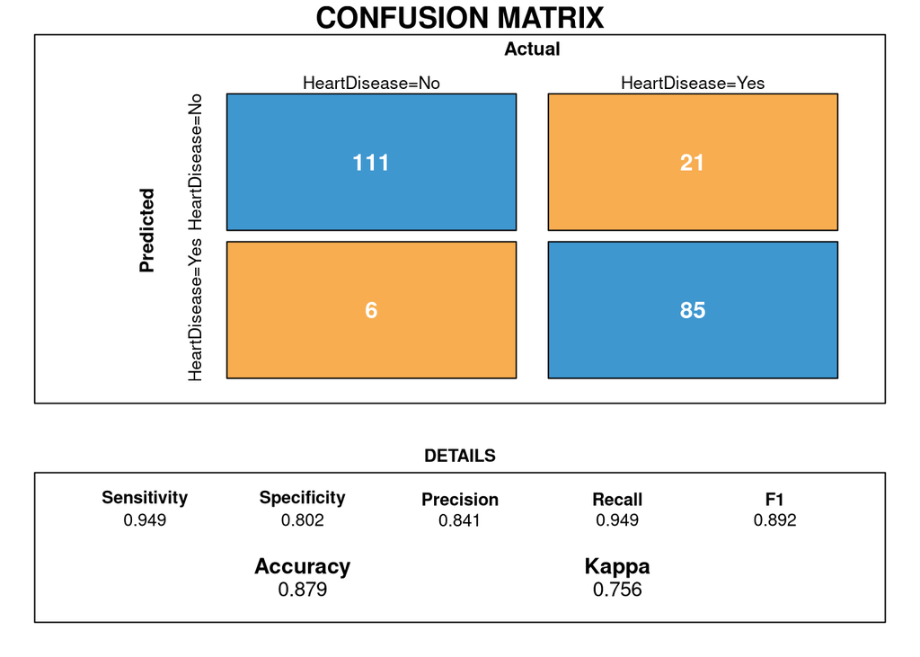

```r
# Predict using the tuned random forest model
predictions2 <- predict(rf_tuned, newdata = test)

# Generate the confusion matrix
cm <- confusionMatrix(predictions2, test$HeartDisease)

# Define the function to draw the confusion matrix
draw_confusion_matrix <- function(cm) {
  layout(matrix(c(1,1,2)))
  par(mar = c(2,2,2,2))
  plot(c(100, 345), c(300, 450), type = "n", xlab="", ylab="", xaxt='n', yaxt='n')
  title('CONFUSION MATRIX', cex.main=2)

  # Matrix layout
  rect(150, 430, 240, 370, col = '#3F97D0')
  text(195, 435, 'HeartDisease=No', cex = 1.2)
  rect(250, 430, 340, 370, col = '#F7AD50')
  text(295, 435, 'HeartDisease=Yes', cex = 1.2)
  text(125, 370, 'Predicted', cex = 1.3, srt = 90, font = 2)
  text(245, 450, 'Actual', cex = 1.3, font = 2)
  rect(150, 305, 240, 365, col = '#F7AD50')
  rect(250, 305, 340, 365, col = '#3F97D0')
  text(140, 400, 'HeartDisease=No', cex = 1.2, srt = 90)
  text(140, 335, 'HeartDisease=Yes', cex = 1.2, srt = 90)

  # Confusion matrix values
  res <- as.numeric(cm$table)
  text(195, 400, res[1], cex = 1.6, font = 2, col = 'white')
  text(195, 335, res[2], cex = 1.6, font = 2, col = 'white')
  text(295, 400, res[3], cex = 1.6, font = 2, col = 'white')
  text(295, 335, res[4], cex = 1.6, font = 2, col = 'white')

  # Metrics display
  plot(c(100, 0), c(100, 0), type = "n", xlab="", ylab="", main = "DETAILS", xaxt='n', yaxt='n')
  text(10, 85, names(cm$byClass[1]), cex = 1.2, font = 2)
  text(10, 70, round(as.numeric(cm$byClass[1]), 3), cex = 1.2)
  text(30, 85, names(cm$byClass[2]), cex = 1.2, font = 2)
  text(30, 70, round(as.numeric(cm$byClass[2]), 3), cex = 1.2)
  text(50, 85, names(cm$byClass[5]), cex = 1.2, font = 2)
  text(50, 70, round(as.numeric(cm$byClass[5]), 3), cex = 1.2)
  text(70, 85, names(cm$byClass[6]), cex = 1.2, font = 2)
  text(70, 70, round(as.numeric(cm$byClass[6]), 3), cex = 1.2)
  text(90, 85, names(cm$byClass[7]), cex = 1.2, font = 2)
  text(90, 70, round(as.numeric(cm$byClass[7]), 3), cex = 1.2)

  # Overall accuracy and kappa
  text(30, 35, names(cm$overall[1]), cex = 1.5, font = 2)
  text(30, 20, round(as.numeric(cm$overall[1]), 3), cex = 1.4)
  text(70, 35, names(cm$overall[2]), cex = 1.5, font = 2)
  text(70, 20, round(as.numeric(cm$overall[2]), 3), cex = 1.4)
}

# Run the function to visualize
draw_confusion_matrix(cm)
```

(Figure 5: Confusion Matrix for Tuned Random Forest Model)

Figure 6 below shows ROC Curve with AUC Score for both models. The basic random forest model had AUC score of .8837 and the tuned random forest model’s ROC curve with an AUC score of 0.9371. This score suggests remarkable classification ability.

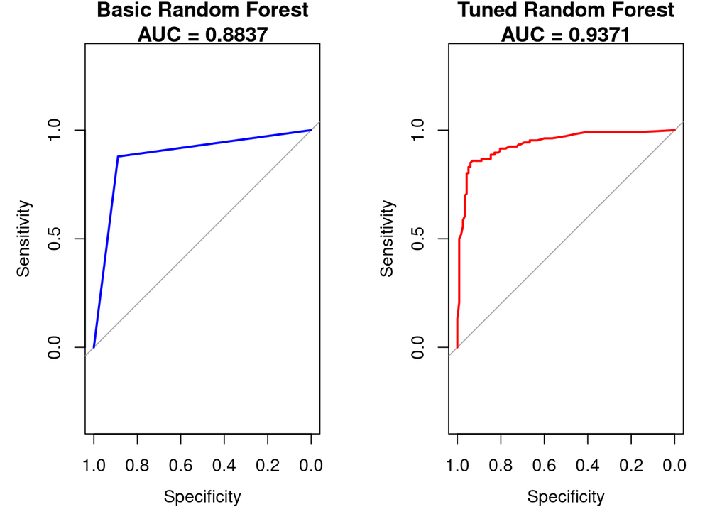

```r
rf_roc2 <- roc(response = test$HeartDisease, predictor = rf_probs, levels = c("No", "Yes"))
auc_value2 <- auc(rf_roc2)

par(mfrow = c(1, 2))

# Basic Model ROC
plot(rf_roc1,
     main = paste("Basic Random Forest\nAUC =", round(auc_value1, 4)),
     col = "blue",
     lwd = 2)

# Tuned Model ROC
plot(rf_roc2,
     main = paste("Tuned Random Forest\nAUC =", round(auc_value2, 4)),
     col = "red",
     lwd = 2)
```

```r
par(mfrow = c(1, 1))
```

(Figure 6: ROC curve with an AUC score of both basic RF Model & tuned RF Model)

The ROC (Receiver Operating Characteristic) curve displays the balance of sensitivity (true positive rate) against specificity (false positive rate) for different thresholds. From the figure we can see that AUC score of tuned model is notably higher than AUC score of basic model of 0.8837. The provided tuned model’s AUC score of 0.9371 is indicative of the strong power of the model in accurately classifying patients with heart disease from those without it. This shows how hyperparameter tuning can optimize accurately and reliably diagnosing heart disease.The AUC value, derived from the ROC curve, indicates strong discriminatory ability. An AUC above 0.90 is typically considered excellent(Fawcett 2006). This means the model is highly effective at distinguishing between patients with and without heart disease, regardless of classification threshold.

We also looked for feature importance, which showed ST_SlopeUp, ChestPainTypeASY, and ST_SlopeFlat to be some of the most important predictors. This is consistent with medical domain knowledge since changes in ST segments and chest pain types are known markers of cardiac abnormality (Khalilia, Chakraborty, and Popescu 2011). The model’s ability to capture meaningful physiological patterns is also supported by the high ranking of MaxHR and Oldpeak.

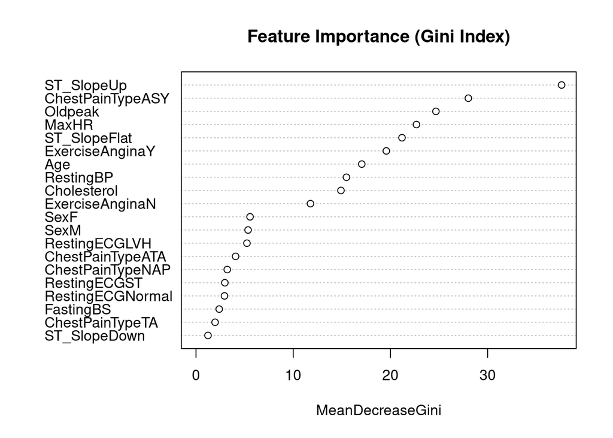

```r
set.seed(123)
rf_model <- randomForest(HeartDisease ~ ., data = train, ntree = 100, importance = TRUE)

# View raw importance values
#importance(rf_model)

# Plot the feature importance
varImpPlot(rf_model,
           type = 2,
           main = "Feature Importance (Gini Index)",
           col = "black")
```

(Figure 7. Feature importance based on the average decrease in Gini index.)

### Conclusion

The aim of the study was to evaluate the Random Forest algorithm. Using a data set to predict heart disease, we compared the results using default settings against a model that was optimized after hyperparameter tuning. Both models provided satisfactory classification properties (>80% accuracy), but the optimized model significantly showed improvement when compared against the initial model when comparing AUC values. Model 1 (default hyperparameters) had an AUC = 0.8837, whereas Model 2 (tuned) had an AUC = 0.9371. This shows that model 2 is better in discriminating between patients with and without heart disease.

From a practical perspective, this study has important implications for the use of Random Forests in clinical decision support. The algorithm’s robust nature and ability to handle various data types makes it an excellent algorithm for healthcare applications. The performance gain after tuning implies that we should not use a Random Forest with default hyperparameters in a real-world machine learning deployment, but it can be used as a baseline for beginning evaluation or determining which model type may be most appropriate.

In conclusion, the Random Forest algorithm is an effective algorithm in medical prediction tasks, as well as various classification and regression problems. Random Forest can provide healthcare professionals with substantial support in terms of early diagnostics and risk stratification if it is tuned correctly, which can lead to improved patient outcomes and optimal use of clinical resources.

## References

Biau, Gérard, and Erwan Scornet. 2016. “A Random Forest Guided Tour.” *Test* 25 (2): 197–227. https://link.springer.com/article/10.1007/s11749-016-0481-7.

Boulesteix, Anne-Laure, Silke Janitza, Jochen Kruppa, and Inke R König. 2012. “Overview of Random Forest Methodology and Practical Guidance with Emphasis on Computational Biology and Bioinformatics.” *Wiley Interdisciplinary Reviews: Data Mining and Knowledge Discovery* 2 (6): 493–507. https://doi.org/10.1002/widm.1072.

Breiman, Leo. 2001. “Random Forests.” *Machine Learning* 45 (1): 5–32. https://link.springer.com/article/10.1023/A:1010933404324.

Dai, Bin, Rung-Ching Chen, Shun-Zhi Zhu, and Wei-Wei Zhang. 2018. “Using Random Forest Algorithm for Breast Cancer Diagnosis.” In *2018 International Symposium on Computer, Consumer and Control (IS3C)*, 449–52. IEEE. https://doi.org/10.1109/IS3C.2018.00119.

Fawcett, Tom. 2006. “An Introduction to ROC Analysis.” *Pattern Recognition Letters* 27 (8): 861–74. https://doi.org/10.1016/j.patrec.2005.10.010.

Khalilia, Mohammed, Sounak Chakraborty, and Mihail Popescu. 2011. “Predicting Disease Risks from Highly Imbalanced Data Using Random Forest.” *BMC Medical Informatics and Decision Making* 11: 1–13. https://doi.org/10.1186/1472-6947-11-51.

Khine, Wai Wai, and Zaw Tun. 2022. “Diabetes Prediction Based on Machine Learning Algorithms: MNB, Random Forest, SVM.” *IEEE Access*. https://ieeexplore.ieee.org/stamp/stamp.jsp?tp=&arnumber=10754937.

Mbonyinshuti, François, Jean Nshimiyimana, and Claude Uwitonze. 2022. “Application of Random Forest Model to Predict the Demand of Essential Medicines for Non-Communicable Diseases Management in Public Health Facilities.” *Pan African Medical Journal* 42: 89. https://pmc.ncbi.nlm.nih.gov/articles/PMC9379432/.

Oshiro, Thais Mayumi, Pedro Santoro Perez, and José Augusto Baranauskas. 2012. “How Many Trees in a Random Forest?” In *Machine Learning and Data Mining in Pattern Recognition: 8th International Conference, MLDM 2012, Berlin, Germany, July 13-20, 2012. Proceedings 8*, 154–68. Springer. https://doi.org/10.1007/978-3-642-31537-4_13.

Probst, Philipp, Marvin N. Wright, and Anne-Laure Boulesteix. 2019a. “Random Forest Algorithms in Health Care Sectors: A Review of Applications.” *Wiley Interdisciplinary Reviews: Data Mining and Knowledge Discovery* 9 (3): e1301. https://www.researchgate.net/publication/358128515_Random_Forest_Algorithms_in_Health_Care_Sectors_A_Review_of_Applications.

Probst, Philipp, Marvin N Wright, and Anne-Laure Boulesteix. 2019b. “Hyperparameters and Tuning Strategies for Random Forest.” *Wiley Interdisciplinary Reviews: Data Mining and Knowledge Discovery* 9 (3): e1301. https://doi.org/10.1002/widm.1301.

Rigatti, Steven J. 2017. “Random Forest.” *Journal of Insurance Medicine* 47 (1): 31–39. https://doi.org/10.17849/insm-47-01-31-39.1.

Viera, Anthony J, and Joanne M Garrett. 2005. “Understanding Interobserver Agreement: The Kappa Statistic.” *Family Medicine* 37 (5): 360–63.